# Ejercicio german

Amanda Balderas

**Cargamos librerias**

```r
library(dplyr)
library(stringr)
```

```r
library(ggplot2)
```

**Definimos directorio de trabajo**

```r
setwd("~/GitHub/itam-dm/alumnos/Amanda/german")
```

**Leemos los datos utilizando 0-load.r**

```r
source(file = '0-load.r')
```

**Veamos la estructura original de los datos**

```r
head(german.data)
```

```
##   Status of existing checking account Duration in month Credit history
## 1                                 A11                 6            A34
## 2                                 A12                48            A32
## 3                                 A14                12            A34
## 4                                 A11                42            A32
## 5                                 A11                24            A33
## 6                                 A14                36            A32
##   Purpose Credit amount Savings account/bonds Present employment since
## 1     A43          1169                   A65                      A75
## 2     A43          5951                   A61                      A73
## 3     A46          2096                   A61                      A74
## 4     A42          7882                   A61                      A74
## 5     A40          4870                   A61                      A73
## 6     A46          9055                   A65                      A73
##   Installment rate in percentage of disposable income
```

[output cut: 41 more lines]

**Preparamos la base utilizando 1-prepare.r**

```r
source(file = '1-prepare.r')
```

### Ejercicio

- ¿Hay algo raro con los datos de préstamo?

Para verificar como se comportan los datos de préstamo, obtenemos un resumen

```r
summary(german.data$Good.Loan)
```

```
##  BadLoan GoodLoan
##      300      700
```

Se puede observar que hay una mayor cantidad de buenos, teniendo un 70%.

- ¿Cuál crees que debería ser la distribución del resultado del préstamo Good.Loan respecto a Credit history?

A mejor historial crediticio, un buen resultado de préstamo.

Obtenemos un resumen de resultados de préstamo agrupando por historial crediticio y observamos que en cuentas criticas/ con otros creditos, representan una importante catidad de préstamos buenos.

```r
agrupa<- group_by(german.data, 'Good.Loan','Credit history')
conteo_agrupa <- summarise(agrupa, n=n())
credit.history.df <- as.data.frame(conteo_agrupa)
credit.history.df
```

```
##    Good.Loan                                             Credit history
## 1    BadLoan                    all credits at this bank paid back duly
## 2    BadLoan critical account/other credits existing (not at this bank)
## 3    BadLoan                            delay in paying off in the past
## 4    BadLoan                   existing credits paid back duly till now
## 5    BadLoan                no credits taken/all credits paid back duly
## 6   GoodLoan                    all credits at this bank paid back duly
## 7   GoodLoan critical account/other credits existing (not at this bank)
## 8   GoodLoan                            delay in paying off in the past
## 9   GoodLoan                   existing credits paid back duly till now
## 10  GoodLoan                no credits taken/all credits paid back duly
##      n
## 1   28
## 2   50
## 3   28
## 4  169
## 5   25
## 6   21
## 7  243
## 8   60
## 9  361
## 10  15
```

**Obtenemos la gráfica**

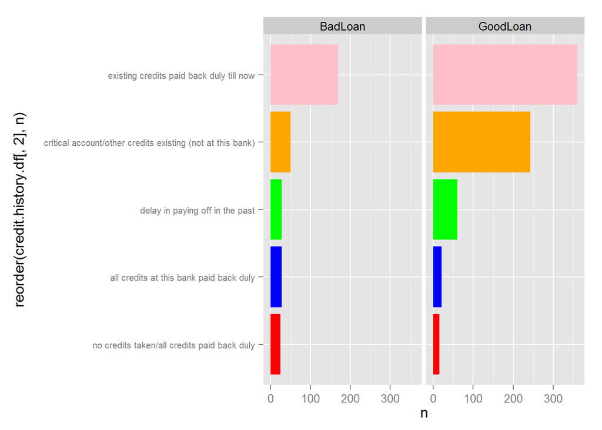

```r
ggplot(credit.history.df, aes(x=reorder(credit.history.df[,2],n), y = n)) +
  geom_bar(stat="identity", fill = c("red", "blue", "green", "orange", "pink")) +
  facet_wrap(~ Good.Loan) +
  coord_flip() +
  theme(axis.text.y=element_text(size=rel(0.8)))
```

Para facilitar la creación de la gráfica vamos a modificar los nombres de la base usando la función rename.

```r
source('utils.r')
nombres <- colnames(german.data)
colnames(german.data) <- rename(nombres)
```

Con lo cambios obtenemos nuevamente nuestra tabla con el resumen de resultados de préstamo agrupando por historial crediticio y observamos que en cuentas criticas/ con otros creditos, representan una importante catidad de préstamos buenos.

```r
agrupa<- group_by(german.data, 'good.loan','credit.history')
conteo_agrupa <- summarise(agrupa, n=n())
credit.history.df <- as.data.frame(conteo_agrupa)
credit.history.df
```

```
##    good.loan                                             credit.history
## 1    BadLoan                    all credits at this bank paid back duly
## 2    BadLoan critical account/other credits existing (not at this bank)
## 3    BadLoan                            delay in paying off in the past
## 4    BadLoan                   existing credits paid back duly till now
## 5    BadLoan                no credits taken/all credits paid back duly
## 6   GoodLoan                    all credits at this bank paid back duly
## 7   GoodLoan critical account/other credits existing (not at this bank)
## 8   GoodLoan                            delay in paying off in the past
## 9   GoodLoan                   existing credits paid back duly till now
## 10  GoodLoan                no credits taken/all credits paid back duly
##      n
## 1   28
## 2   50
## 3   28
## 4  169
## 5   25
## 6   21
## 7  243
## 8   60
## 9  361
## 10  15
```

Ahora obtenemos la misma gráfica de manera más sencilla utilizando los nombres de las variables

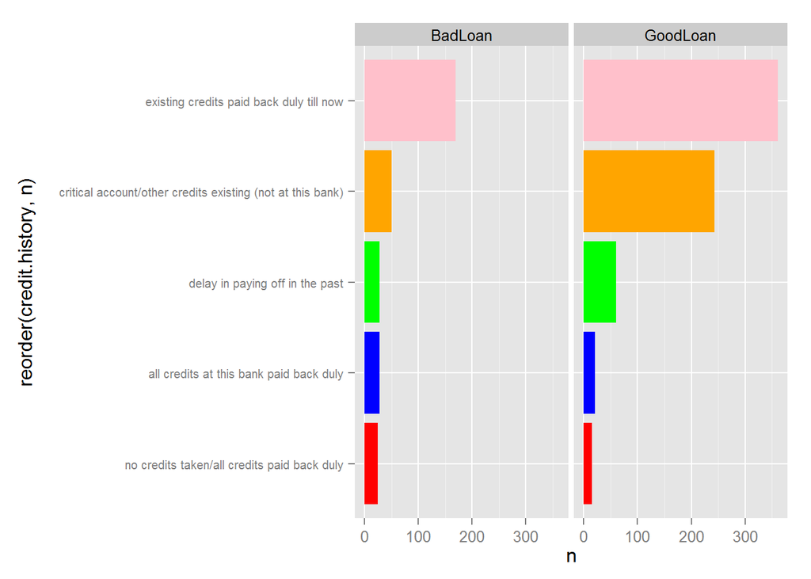

```r
ggplot(credit.history.df, aes(x=reorder(credit.history, n), y = n)) +
  geom_bar(stat="identity", fill = c("red", "blue", "green", "orange", "pink")) +
  facet_wrap(~ good.loan) +
  coord_flip() +
  theme(axis.text.y=element_text(size=rel(0.8)))
```